# PA1_template.Rd

## Introduction

This assignment makes use of data from a personal activity monitoring device. This device collects data at 5 minute intervals through out the day. The data consists of two months of data from an anonymous individual collected during the months of October and November, 2012 and include the number of steps taken in 5 minute intervals each day.

## Data Layout

**DATA:**  
The data for this assignment is available here.

**Overview:**  
The data file is in CSV format and contains 17568 observations.

**Variables:**  
- *steps*: Number of steps taken during a 5 minute interval (missing values coded as NA)  
- *date*: The date on which the measurement was taken with format YYYY-MM-DD  
- *interval*: Identifier for the 5 minute interval in which the measurement has been taken

## Overview

There are 5 steps required to complete this analysis.

1. Loading in and processing the data.
2. Plotting a histogram of the total number of steps taken by day. Additionally, calculate the mean and median total steps taken each day.
3. Determine the average daily activity pattern by creating a time series plot of the average number of steps taken for each 5 minute interval across all days. Then determine which 5 minute interval, on average, has the most steps.
4. Impute the missing values as there are missing values contained in the data set (codes as NA) which can introduce a bias in calculations or summaries. First, we must calculate the number of missing values contained in the dataset. Next, we impute these values using the mean of those days with values for the specified 5 minute time interval. Then we will create a new data set with the missing values filled in by the imputed values. Finally, we will repeat step 2 with the missing values replaced by the imputed values.
5. Finally, we will look for any difference between weekends or weekdays using the dataset that has had its NA values replaced with the imputed values in step 4 by creating a factor variable with two levels, weekend and weekday to identify the appropraite days. We will analyze the average number of steps taken for each interval based on the factor variable and create a time series panel plot for this data.

## 1. Data load and processing

```r
activity <- read.csv("./activity.csv")
summary(activity)
```

```
##      steps                date          interval
##  Min.   :  0.00   2012-10-01:  288   Min.   :   0.0
##  1st Qu.:  0.00   2012-10-02:  288   1st Qu.: 588.8
##  Median :  0.00   2012-10-03:  288   Median :1177.5
##  Mean   : 37.38   2012-10-04:  288   Mean   :1177.5
##  3rd Qu.: 12.00   2012-10-05:  288   3rd Qu.:1766.2
##  Max.   :806.00   2012-10-06:  288   Max.   :2355.0
##  NA's   :2304     (Other)   :15840
```

## 2. Calculate the mean total steps taken per day

1. View a histogram of the total number of steps taken per day.

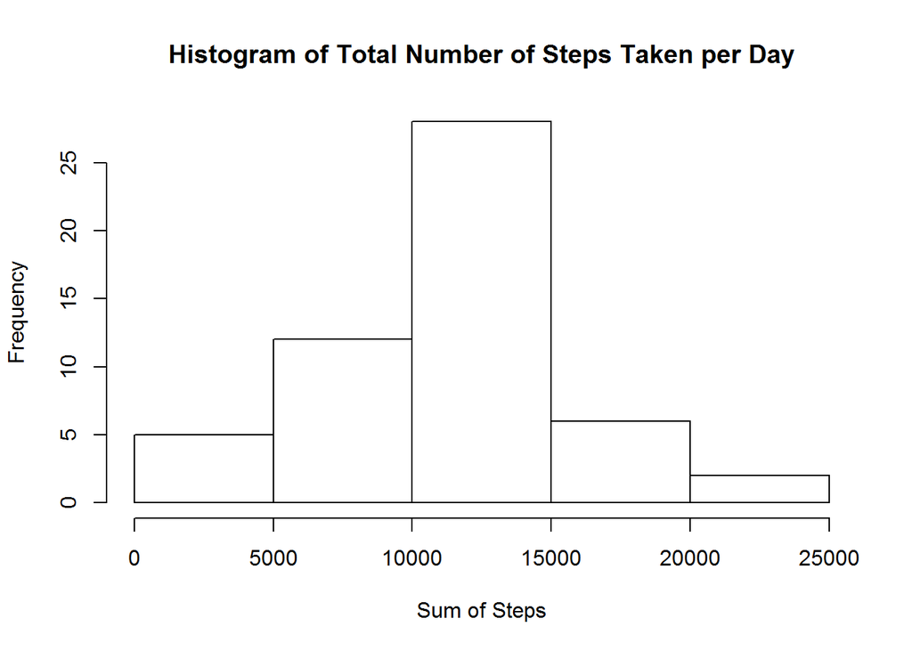

```r
hist(tapply(activity$steps,activity$date,sum), main = paste("Histogram of Total Number of Steps Taken per Day"), xlab="Sum of Steps")
```

2. Calculate the mean and median steps taken per day with the missing values removed.

```r
Steps_mean <- mean(tapply(activity$steps, activity$date, sum), na.rm=TRUE)
Steps_median <- median(tapply(activity$steps, activity$date, sum), na.rm=TRUE)

print(paste0("Mean total number of steps taken per day is: ", Steps_mean), digits = 2)
```

```
## [1] "Mean total number of steps taken per day is: 10766.1886792453"
```

```r
print(paste0("Median total number of steps taken per day is: ", Steps_median))
```

```
## [1] "Median total number of steps taken per day is: 10765"
```

## 3. Analyze the average daily activity pattern

1. Compute the average number of steps and create a time series plot of the computed data.

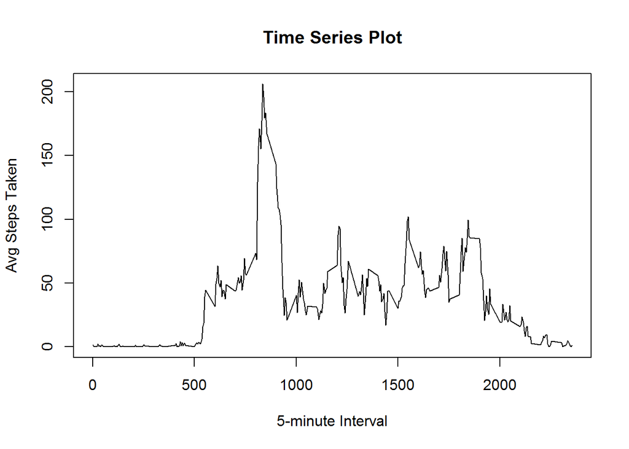

```r
avgSteps <- tapply(activity$steps, activity$interval, mean, na.rm=TRUE)
plot(names(avgSteps), avgSteps, type="l", main = "Time Series Plot", xlab="5-minute Interval", ylab="Avg Steps Taken")
```

2. Find the 5 minute interval which contains the maximum average number of steps taken.

```r
print(paste0("Interval ", as.numeric(names(which.max(avgSteps))) , " contains the maximum number of steps."))
```

```
## [1] "Interval 835 contains the maximum number of steps."
```

## 4. Impute the missing values

1. There are many intervals which contain missing values (coded as NA). The presence of missing days may introduce a bias into some of the calculations or summaries for the data.

```r
missing <- is.na(activity$steps)
table(missing)
```

```
## missing
## FALSE  TRUE
## 15264  2304
```

```r
miss_count <- sum(as.numeric(missing))
print(paste0("The number of missing intervals is: ", miss_count))
```

```
## [1] "The number of missing intervals is: 2304"
```

2. Replace the missing values with the mean value for that 5 minute interval.

```r
mean_Interval <-tapply(activity$steps, activity$interval,mean, na.rm=TRUE)
activity_nomiss <- activity
for (i in which(is.na(activity_nomiss)))
    {
    activity_nomiss[i,1] <- mean_Interval[((i-1)%%288)+1]
}
```

3. Historgram with new dataset

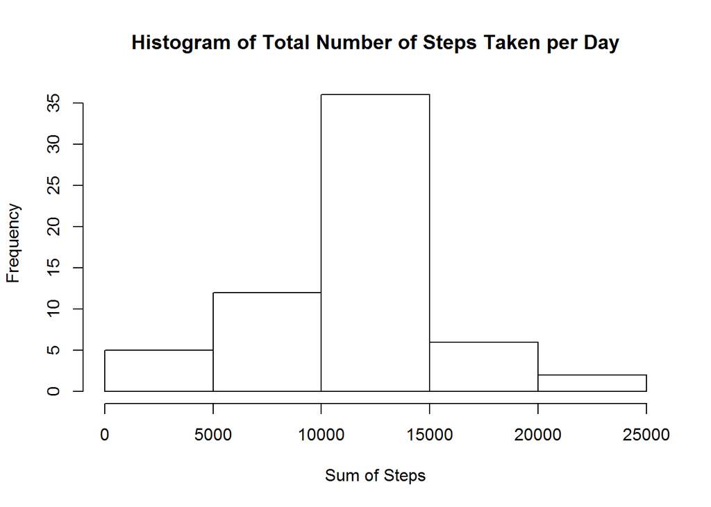

```r
hist(tapply(activity_nomiss$steps,activity_nomiss$date,sum), main = paste("Histogram of Total Number of Steps Taken per Day"), xlab="Sum of Steps")
```

4. Recalculate the mean and median total steps for the day

```r
meanSteps <- mean(tapply(activity_nomiss$steps,activity_nomiss$date,sum), na.rm=TRUE)
medianSteps <- median(tapply(activity_nomiss$steps,activity_nomiss$date,sum), na.rm=TRUE)
print(paste0("Mean total number of steps taken per day is: ", meanSteps), digits = 2)
```

```
## [1] "Mean total number of steps taken per day is: 10766.1886792453"
```

```r
print(paste0("Median total number of steps taken per day is: ", medianSteps))
```

```
## [1] "Median total number of steps taken per day is: 10766.1886792453"
```

Due to the inclusion of the option na.rm = TRUE, the mean value hasn’t changed, but the median value has slightly grown with he additional values. The largest difference caused by adding the imputed values is the increase in the number of steps taken per day, as shown in the histogram.

## 5. Analyze the difference in activity patterns between weekends and weekdays with the imputed data

1. Add a new variable for weekend/weekday to the data set with imputed values.

```r
wkday.or.wkend <- function(date) {
    day <- weekdays(date)
    if (day %in% c("Monday", "Tuesday", "Wednesday", "Thursday", "Friday"))
        return("weekday")
    else if (day %in% c("Saturday", "Sunday"))
        return("weekend")
    else
        stop("invalid date")
}
activity_nomiss$date <- as.Date(activity_nomiss$date)
activity_nomiss$day <- sapply(activity_nomiss$date, FUN=wkday.or.wkend)
```

2. Plot the weekday/weekend charts

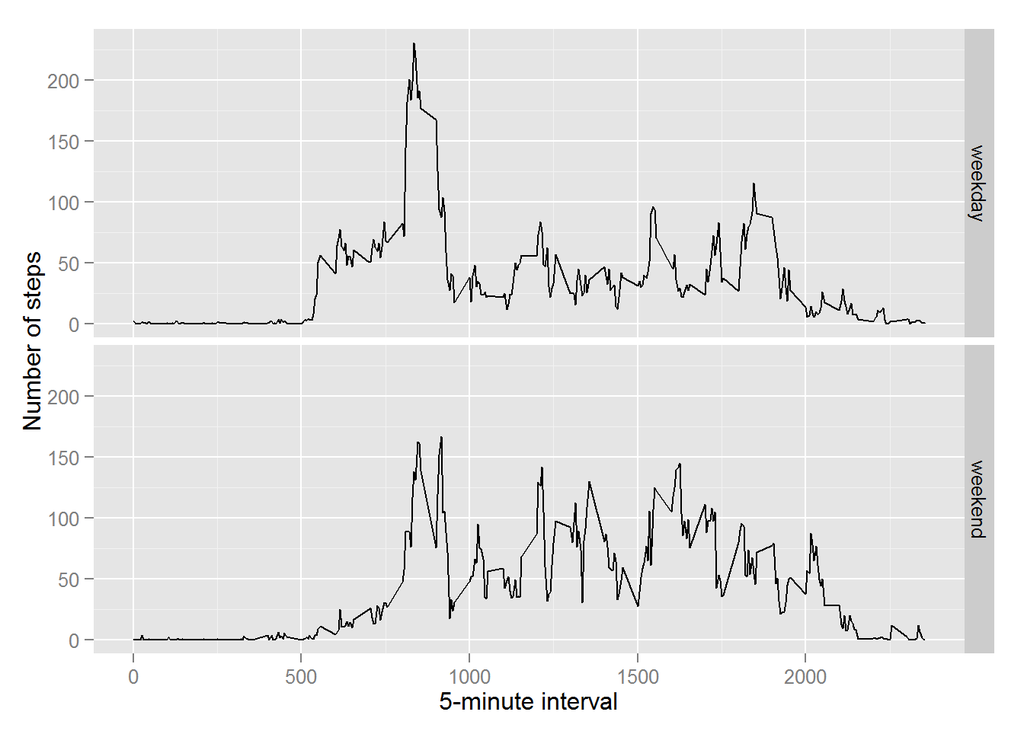

```r
library(ggplot2)
averages <- aggregate(steps ~ interval + day, data=activity_nomiss, mean)
ggplot(averages, aes(interval, steps)) + geom_line() + facet_grid(day ~ .) +
    xlab("5-minute interval") + ylab("Number of steps")
```